# HW2-2

```python
pip install pandas numpy matplotlib seaborn statsmodels
```

```
Downloading tabulate-0.9.0-py3-none-any.whl (35 kB)
```

## task1：读入样本数据data.csv，命名为video，展示数据的变量总体情况。

```python
import pandas as pd

video = pd.read_csv('data.csv')

# 转换单位：点赞、分享、评论转换为万，发布时间精确到分
for col in ['点赞数', '分享数', '评论数']:
    video[col] = video[col] / 10000
video['发布时间'] = pd.to_datetime(video['发布时间'], format='%H:%M:%S', errors='coerce')
video['发布时间'] = video['发布时间'].dt.strftime('%H:%M')

# 展示数据概况
print("数据前5行：")
print(video.head())
print("\n变量总体情况：")
print(video.info())
print("\n描述性统计：")
print(video.describe(include='all').round(2))
```

```
数据前5行：
   序号  作者编号       点赞数     评论数      分享数      BGM     时长       发布日期   发布时间  类别  \
0   1     1  409.3719  0.1035  16.0448  作者创作的原声  15.00   2019/5/6  17:47  美食
1   2     2  326.3395  5.9098  21.4594  作者创作的原声  58.33   2019/1/4  17:17  美食
2   3     2  296.2712  5.2549  10.9605  作者创作的原声  57.60  2019/2/11  17:33  美食
3   4     2  295.3051  5.5461  21.5838  作者创作的原声  50.80  2019/1/26  17:44  美食
4   5     2  282.1680  5.2263  12.5418  作者创作的原声  51.57  2019/1/29  17:06  美食

   标题字数
0    44
1    11
2    12
3    12
4    13

变量总体情况：
<class 'pandas.core.frame.DataFrame'>
RangeIndex: 6400 entries, 0 to 6399
Data columns (total 11 columns):
 #   Column  Non-Null Count  Dtype
---  ------  --------------  -----
 0   序号      6400 non-null   int64
 1   作者编号    6400 non-null   int64
 2   点赞数     6400 non-null   float64
 3   评论数     6400 non-null   float64
 4   分享数     6400 non-null   float64
 5   BGM     6399 non-null   object
 6   时长      6400 non-null   float64
 7   发布日期    6400 non-null   object
 8   发布时间    6400 non-null   object
 9   类别      6400 non-null   object
 10  标题字数    6400 non-null   int64
dtypes: float64(4), int64(3), object(4)
memory usage: 550.1+ KB
None

描述性统计：
             序号     作者编号      点赞数      评论数      分享数      BGM       时长  \
count   6400.00  6400.00  6400.00  6400.00  6400.00     6399  6400.00
unique      NaN      NaN      NaN      NaN      NaN      552      NaN
top         NaN      NaN      NaN      NaN      NaN  作者创作的原声      NaN
freq        NaN      NaN      NaN      NaN      NaN     5503      NaN
mean    3200.50  1280.56    65.14     1.17     2.20      NaN    29.59
std     1847.67   806.89    51.43     1.33     3.44      NaN    17.54
min        1.00     1.00     1.52     0.00     0.00      NaN     4.40
25%     1600.75   531.75    30.94     0.32     0.26      NaN    14.33
50%     3200.50  1331.50    53.90     0.73     0.78      NaN    24.78
75%     4800.25  1992.25    84.44     1.49     2.44      NaN    45.50
max     6400.00  2612.00   455.68    12.02    34.76      NaN    60.04

             发布日期   发布时间    类别     标题字数
count        6400   6400  6400  6400.00
unique        129   1137     7      NaN
top     2019/1/26  18:02    美食      NaN
freq           76     41  1000      NaN
mean          NaN    NaN   NaN    26.71
std           NaN    NaN   NaN    13.68
min           NaN    NaN   NaN     0.00
25%           NaN    NaN   NaN    16.00
50%           NaN    NaN   NaN    26.00
75%           NaN    NaN   NaN    37.00
max           NaN    NaN   NaN    72.00
```

## task2：进行描述性分析，包括但不限于以下方面：

### （1）绘制因变量点赞分布直方图，并进行适当解读；

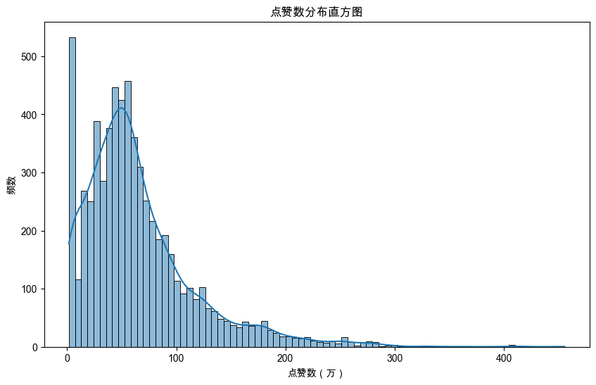

```python
import matplotlib.pyplot as plt
import seaborn as sns

plt.figure(figsize=(10, 6))
plt.rcParams['font.sans-serif'] = ['Arial Unicode MS']
sns.histplot(video['点赞数'], bins=80, kde=True)
plt.title('点赞数分布直方图')
plt.xlabel('点赞数（万）')
plt.ylabel('频数')
plt.show()
```

#### 解读：（1）点赞数呈现明显的右偏分布，绝大多数内容点赞数较低，少数爆款内容获得了极高的点赞数，展示了点赞数分布的“二八定律”甚至“一九定律”（2）点赞数峰值在10万以内，另外，点赞数大量聚集在40-60万区间。

### （2）利用数据集中的发布时间变量，使用折线图展示不同小时发布的短视频点赞数的差异，并进行适当解读；

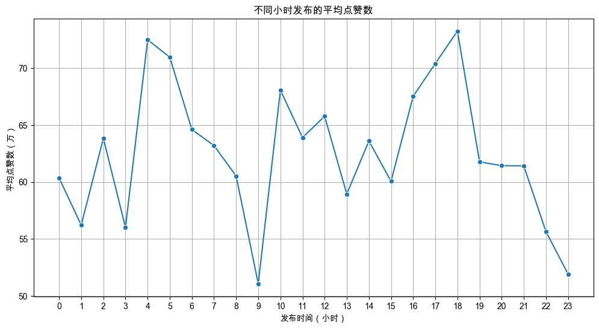

```python
# 提取发布时间的小时
video['发布时间'] = pd.to_datetime(video['发布时间'], format='%H:%M').dt.hour
# 按小时分组计算平均点赞数
hourly_avg = video.groupby('发布时间')['点赞数'].mean().reset_index()
# 绘制折线图
plt.figure(figsize=(12, 6))
sns.lineplot(x='发布时间', y='点赞数', data=hourly_avg, marker='o')
plt.title('不同小时发布的平均点赞数')
plt.xlabel('发布时间（小时）')
plt.ylabel('平均点赞数（万）')
plt.xticks(range(0, 24))
plt.grid(True)
plt.show()
```

### （3）请使用分组箱线图对比不同类别的视频的点赞数差异，并进行适当解读。

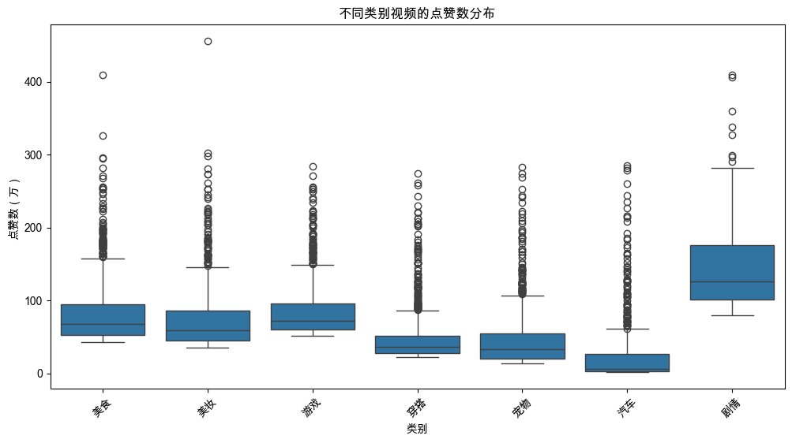

```python
plt.figure(figsize=(12, 6))
sns.boxplot(x='类别', y='点赞数', data=video)
plt.title('不同类别视频的点赞数分布')
plt.xlabel('类别')
plt.ylabel('点赞数（万）')
plt.xticks(rotation=45)
plt.show()
```

## task3：对非汽车类数据进行线性回归建模分析。将视频发布时间分为6个时段，将该变量命名为“视频发布时间”。建立点赞数的双对数线性回归模型，因变量为对数点赞数，自变量包括：视频发布时段（基准组：夜间）、对数分享数、对数评论数、时长、类别（基准组：宠物）、标题字数，并对结果进行适当解读。

```python
import numpy as np
import statsmodels.formula.api as smf

# 过滤汽车类数据
video_noncar = video[video['类别'] != '汽车']

# 定义发布时间分段函数
def get_period(hour):
    if 20 <= hour or hour < 6:
        return '夜间'
    elif 6 <= hour < 9:
        return '早间'
    elif 9 <= hour < 12:
        return '上午'
    elif 12 <= hour < 14:
        return '中午'
    elif 14 <= hour < 17:
        return '下午'
    else:
        return '傍晚'
video_noncar['视频发布时间'] = video_noncar['发布时间'].apply(get_period)

# 对数转换
video_noncar['log_点赞数'] = np.log(video_noncar['点赞数'])
video_noncar['log_分享数'] = np.log(video_noncar['分享数'])
video_noncar['log_评论数'] = np.log(video_noncar['评论数'])

# 线性回归模型
formula = '''
log_点赞数 ~ C(视频发布时间, Treatment("夜间")) + log_分享数 + log_评论数 +
时长 + C(类别, Treatment("宠物")) + 标题字数
'''
model = smf.ols(formula, data=video_noncar).fit()
print(model.summary())
```

```
                            OLS Regression Results
==============================================================================
Dep. Variable:                log_点赞数   R-squared:                       0.618
Model:                            OLS   Adj. R-squared:                  0.617
Method:                 Least Squares   F-statistic:                     621.6
Date:                Sun, 16 Mar 2025   Prob (F-statistic):               0.00
Time:                        16:33:33   Log-Likelihood:                -2570.5
No. Observations:                5400   AIC:                             5171.
Df Residuals:                    5385   BIC:                             5270.
Df Model:                          14
Covariance Type:            nonrobust
====================================================================================================
                                       coef    std err          t      P>|t|      [0.025      0.975]
----------------------------------------------------------------------------------------------------
Intercept                            3.6999      0.022    164.468      0.000       3.656       3.744
C(视频发布时间, Treatment("夜间"))[T.上午]     0.0165      0.019      0.858      0.391      -0.021       0.054
C(视频发布时间, Treatment("夜间"))[T.下午]     0.0170      0.021      0.814      0.416      -0.024       0.058
C(视频发布时间, Treatment("夜间"))[T.中午]     0.0323      0.021      1.548      0.122      -0.009       0.073
C(视频发布时间, Treatment("夜间"))[T.傍晚]     0.0445      0.017      2.572      0.010       0.011       0.078
C(视频发布时间, Treatment("夜间"))[T.早间]     0.0054      0.028      0.192      0.848      -0.050       0.060
C(类别, Treatment("宠物"))[T.剧情]         0.8239      0.026     32.221      0.000       0.774       0.874
C(类别, Treatment("宠物"))[T.游戏]         0.5393      0.018     29.714      0.000       0.504       0.575
C(类别, Treatment("宠物"))[T.穿搭]         0.0290      0.018      1.625      0.104      -0.006       0.064
C(类别, Treatment("宠物"))[T.美妆]         0.3424      0.018     18.731      0.000       0.307       0.378
C(类别, Treatment("宠物"))[T.美食]         0.4238      0.019     22.867      0.000       0.387       0.460
log_分享数                              0.0995      0.004     23.373      0.000       0.091       0.108
log_评论数                              0.2302      0.006     37.140      0.000       0.218       0.242
时长                                   0.0028      0.000      8.227      0.000       0.002       0.003
标题字数                                 0.0013      0.000      3.301      0.001       0.001       0.002
==============================================================================
Omnibus:                       98.137   Durbin-Watson:                   0.756
Prob(Omnibus):                  0.000   Jarque-Bera (JB):              106.729
Skew:                           0.306   Prob(JB):                     6.67e-24
Kurtosis:                       3.317   Cond. No.                         327.
==============================================================================

Notes:
[1] Standard Errors assume that the covariance matrix of the errors is correctly specified.
```

#### （1）R²=0.618，F统计量p值=0.00，模型总体解释能力较强。（2）傍晚发布效果最佳：相比夜间参考组，傍晚发布的系数为 0.0445（p=0.010），显著提升点赞数。其他时段无显著差异，系数均不显著。（3）视频类别：剧情类表现最强，相比宠物类，剧情类的系数为 0.8239（p=0.000），意味着点赞数是宠物类的 2.28倍（e^0.8239≈2.28）。游戏、美食、美妆均显著优于宠物类，穿搭类无显著差异，与宠物类效果相近。

## task4：对建立的模型进行模型诊断，输出结果，并进行适当解读。

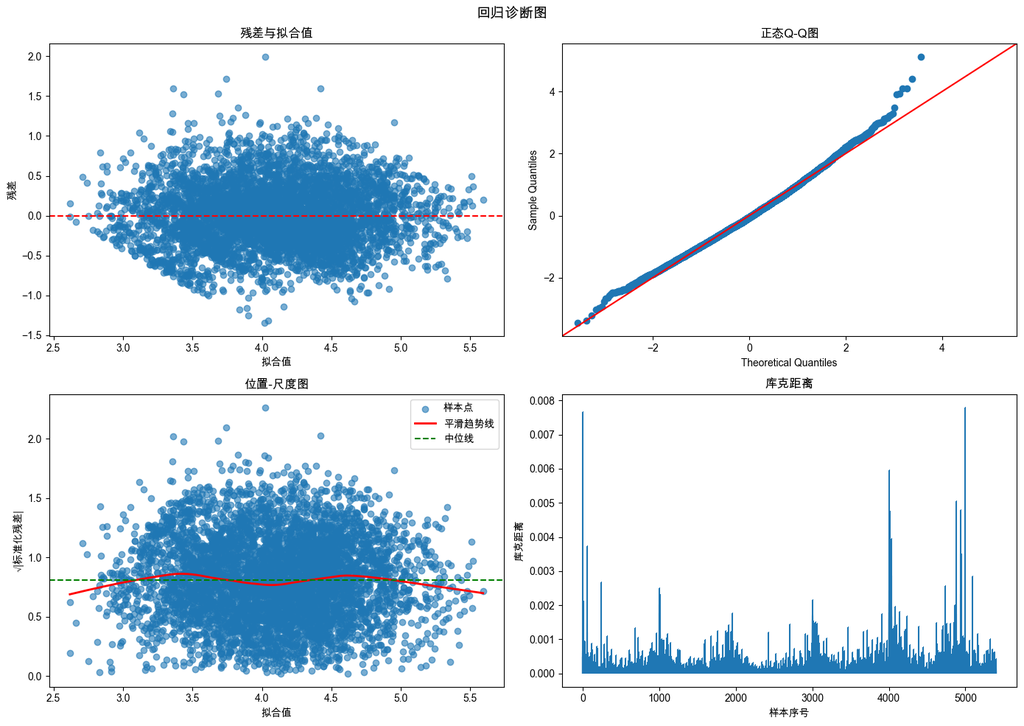

```
VIFs: [2.02 1.75 1.76 2.47 1.32 1.59 1.76 1.71 1.79 1.84 1.36 1.43 1.24 1.05]
```

```python
import matplotlib.pyplot as plt
import statsmodels.api as sm
from statsmodels.stats.outliers_influence import OLSInfluence

# 获取模型诊断所需数据
fitted_values = model.fittedvalues
residuals = model.resid
student_resid = model.get_influence().resid_studentized_external
cooks_distance = OLSInfluence(model).cooks_distance[0]

# 创建画布
fig = plt.figure(figsize=(14, 10))
fig.suptitle('回归诊断图', fontsize=14)

# 1. 残差 vs 拟合值
ax1 = plt.subplot(2, 2, 1)
ax1.scatter(fitted_values, residuals, alpha=0.6)
ax1.axhline(y=0, color='red', linestyle='--')
ax1.set_xlabel('拟合值')
ax1.set_ylabel('残差')
ax1.set_title('残差与拟合值')

# 2. 正态Q-Q图
ax2 = plt.subplot(2, 2, 2)
sm.qqplot(residuals, line='45', fit=True, ax=ax2)
ax2.set_title('正态Q-Q图')

# 3. 位置-尺度图（标准化残差 vs 拟合值）
from statsmodels.nonparametric.smoothers_lowess import lowess
sqrt_abs_resid = np.sqrt(np.abs(student_resid))
smooth_line = lowess(sqrt_abs_resid, fitted_values, frac=0.3)
ax3 = plt.subplot(2, 2, 3)
ax3.scatter(fitted_values, sqrt_abs_resid, alpha=0.6, label='样本点')
ax3.plot(smooth_line[:, 0], smooth_line[:, 1], color='red', linewidth=2, label='平滑趋势线')
ax3.axhline(y=np.nanmedian(sqrt_abs_resid), color='green', linestyle='--', label='中位线')
ax3.set_xlabel('拟合值')
ax3.set_ylabel('√|标准化残差|')
ax3.set_title('位置-尺度图')
ax3.legend()

# 4. 库克距离图
ax4 = plt.subplot(2, 2, 4)
ax4.stem(np.arange(len(cooks_distance)), cooks_distance, markerfmt=",", basefmt=" ")
#ax4.axhline(y=4/len(cooks_distance), color='red', linestyle='--')
ax4.set_xlabel('样本序号')
ax4.set_ylabel('库克距离')
ax4.set_title('库克距离')

plt.tight_layout()
plt.show()

#5.多重共线性检查（VIF）
from statsmodels.stats.outliers_influence import variance_inflation_factor
vifs = [variance_inflation_factor(model.model.exog, i) for i in range(1, model.model.exog.shape[1])]  # 排除截距项
print(f'VIFs: {np.round(vifs, 2)}')
```